# BELLA BEAT CASE STUDY

# 5. ANALYZE AND SHARE PHASE

We analyze the trends of FitBit users in order to help us make informed BellaBeat marketing strategies.

We want to ascertain the type of users with the data we have because we don’t have any demographic information from our sample. We can categorize people based on their daily number of steps using this information provided by [CDC](https://www.10000steps.org.au/articles/counting-steps/).

- Sedentary is less than 5,000 steps per day
- Low active is 5,000 to 7,499 steps per day
- Somewhat active is 7,500 to 9,999 steps per day
- Active is more than 10,000 steps per day
- Highly active is more than 12,500

We calculate the daily average steps by the user

```r
daily_average <- daily_activity_sleep %>%
  group_by(Id) %>%
  summarise(mean_daily_steps = mean(TotalSteps), mean_daily_calories = mean(Calories), mean_daily_sleep = mean(TotalMinutesAsleep))

head(daily_average)
```

| Id | mean_daily_steps | mean_daily_calories | mean_daily_sleep |
| --- | --- | --- | --- |
| 1503960366 | 12405.680 | 1872.280 | 360.2800 |
| 1644430081 | 7967.750 | 2977.750 | 294.0000 |
| 1844505072 | 3477.000 | 1676.333 | 652.0000 |
| 1927972279 | 1490.000 | 2316.200 | 417.0000 |
| 2026352035 | 5618.679 | 1540.786 | 506.1786 |
| 2320127002 | 5079.000 | 1804.000 | 61.0000 |

We use the daily_average steps to classify our users

```r
user_type <- daily_average %>%
  mutate(user_type = case_when(
    mean_daily_steps < 5000 ~ "sedentary",
    mean_daily_steps >= 5000 & mean_daily_steps < 7499 ~ "lightly active",
    mean_daily_steps >= 7500 & mean_daily_steps < 9999 ~ "fairly active",
    mean_daily_steps >= 10000 ~ "very active"
  ))

head(user_type)
```

| Id | mean_daily_steps | mean_daily_calories | mean_daily_sleep | user_type |
| --- | --- | --- | --- | --- |
| 1503960366 | 12405.680 | 1872.280 | 360.2800 | very active |
| 1644430081 | 7967.750 | 2977.750 | 294.0000 | fairly active |
| 1844505072 | 3477.000 | 1676.333 | 652.0000 | sedentary |
| 1927972279 | 1490.000 | 2316.200 | 417.0000 | sedentary |
| 2026352035 | 5618.679 | 1540.786 | 506.1786 | lightly active |
| 2320127002 | 5079.000 | 1804.000 | 61.0000 | lightly active |

We will create a data frame with the percentage of each user type now that we have a new column with the user type to better visualise them on a graph.

```r
user_type_percent <- user_type %>%
  group_by(user_type) %>%
  summarise(total = n()) %>%
  mutate(totals = sum(total)) %>%
  group_by(user_type) %>%
  summarise(total_percent = total / totals) %>%
  mutate(labels = scales::percent(total_percent))

user_type_percent$user_type <- factor(user_type_percent$user_type , levels = c("very active", "fairly active", "lightly active", "sedentary"))


head(user_type_percent)
```

| user_type | total_percent | labels |
| --- | --- | --- |
| fairly active | 0.3750000 | 38% |
| lightly active | 0.2083333 | 21% |
| sedentary | 0.2083333 | 21% |
| very active | 0.2083333 | 21% |

We can infer from this table that the all the user type wear their smart devices based on user activity.

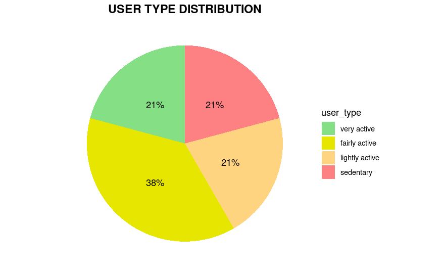

```r
user_type_percent %>%
  ggplot(aes(x="",y=total_percent, fill=user_type)) +
  geom_bar(stat = "identity", width = 1)+
  coord_polar("y", start=0)+
  theme_minimal()+
  theme(axis.title.x= element_blank(),
        axis.title.y = element_blank(),
        panel.border = element_blank(),
        panel.grid = element_blank(),
        axis.ticks = element_blank(),
        axis.text.x = element_blank(),
        plot.title = element_text(hjust = 0.5, size=14, face = "bold")) +
  scale_fill_manual(values = c("#85e085","#e6e600", "#ffd480", "#fd8083")) +
  geom_text(aes(label = labels),
            position = position_stack(vjust = 0.5))+
  labs(title="USER TYPE DISTRIBUTION")
```

## 5.1 Steps and minutes asleep per weekday

We want to know which days of the week users are the most active and which days of the week users sleep the most. We will also check to see if the users are taking the required number of steps and getting enough sleep.

The weekdays are calculated below depending on our column date. We are also estimating the average number of steps taken and minutes slept per weekday.

```r
weekday_steps_sleep <- daily_activity_sleep %>%
  mutate(weekday = weekdays(date))

weekday_steps_sleep$weekday <-ordered(weekday_steps_sleep$weekday, levels=c("Monday", "Tuesday", "Wednesday", "Thursday",
"Friday", "Saturday", "Sunday"))


weekday_steps_sleep <-weekday_steps_sleep%>%
  group_by(weekday) %>%
  summarize (daily_steps = mean(TotalSteps), daily_sleep = mean(TotalMinutesAsleep))

head(weekday_steps_sleep)
```

| weekday | daily_steps | daily_sleep |
| --- | --- | --- |
| Monday | 9273.217 | 419.5000 |
| Tuesday | 9182.692 | 404.5385 |
| Wednesday | 8022.864 | 434.6818 |
| Thursday | 8183.516 | 401.2969 |
| Friday | 7901.404 | 405.4211 |
| Saturday | 9871.123 | 419.0702 |

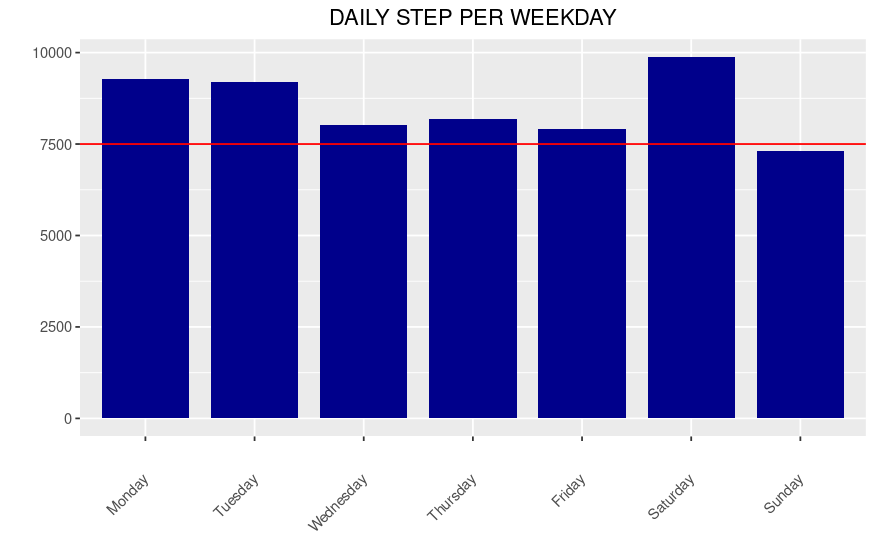

```r
ggplot(weekday_steps_sleep)+
  geom_col(aes(weekday, daily_steps), fill= "darkblue", width = 0.8)+
  geom_hline(yintercept = 7500, colour ="red")+
  labs(title = "DAILY STEP PER WEEKDAY", x= " ", y = " ")+
  theme(plot.title = element_text(hjust = 0.5),axis.text.x = element_text(angle = 45,vjust = 0.5, hjust = 1) )
```

From this graph we can infer that Fitbit Users walk an average of 7500 steps daily asides sundays which according to CDC’s reccommendation falls under “somewhat active”.

Researchers found that, in a study published on March 24, 2020, in the Journal of the American Medical Association, “taking 8,000 steps per day was associated with a 51% lower risk for all-cause mortality (or death from all causes), compared with taking 4,000 steps per day, a number considered to be low for adults.” Compared to 4,000 steps a day, walking 12,000 steps was linked to a 65% decreased risk.

For most adults, the CDC advises taking 8,000 steps a day, with a goal of 10,000 steps. **Although we had 7500 it’s averagely okay but could be much better.**

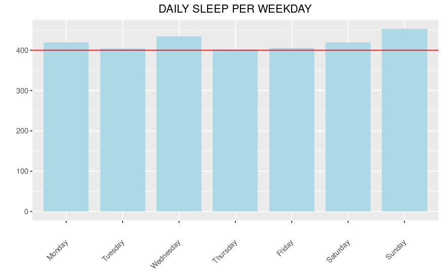

```r
ggplot(weekday_steps_sleep)+
  geom_col(aes(weekday, daily_sleep), fill= "lightblue",width = 0.8)+
  geom_hline(yintercept = 400, colour ="red")+
  labs(title = "DAILY SLEEP PER WEEKDAY", x= " ", y = " ")+
  theme(plot.title = element_text(hjust = 0.5),axis.text.x = element_text(angle = 45,vjust = 0.5, hjust = 1) )
```

From this graph we can infer that Fitbit users sleep and average of 400 minutes daily with sunday having the highest time spent sleeping owing to possibly less activity(weekend).

However 400 minutes which is equivalent to 6.67 hours daily is below the reccommended sleep by CDC for adults which is 8 hours.

We want to ascertain the the time users were more/least active during the day using the hourly steps dataset

```r
hourly_steps <- hourly_steps %>%
  rename(date_time = ActivityHour) %>%
  separate(date_time, into = c("date", "time"), sep = " ") %>%
  mutate(date = ymd(date))
```

[output not shown]

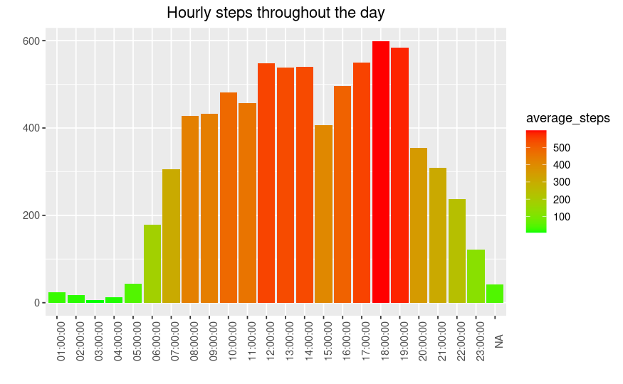

```r
hourly_steps %>%
  group_by(time) %>%
  summarize(average_steps = mean(StepTotal)) %>%
  ggplot() +
  geom_col(mapping = aes(x=time, y = average_steps, fill = average_steps)) +
  labs(title = "Hourly steps throughout the day", x="", y="") +
  theme(plot.title = element_text(hjust = 0.5))+
  scale_fill_gradient(low = "green", high = "red")+
  theme(axis.text.x = element_text(angle = 90))
```